# P8105_hw2_zf2212

Zhiqian Fang

9/28/2018

## Problem 1

This problem focuses on NYC Transit data; in particular, this CSV file contains information related to each entrance and exit for each subway station in NYC.

```r
# Load the library
library(tidyverse)
# Read and clean the data, retain useful variables, convert the entry variable
nyc_data = read_csv(file = "./data/NYC_Transit_Subway_Entrance_And_Exit_Data.csv") %>%
  janitor::clean_names() %>%
  select(line, station_name, station_latitude, station_longitude, route1:route11, entry, vending, entrance_type, ada) %>%
  mutate(entry, entry = ifelse(entry == "YES", TRUE, FALSE))
```

The dataset above contains **information about NYC transit**, including line, station name, station latitude, station longitude, routes, entry, vending, entrance type and ADA compliance information.

I retain useful data. Convert the entry variable from YES or NO to a logical variable.

The **dimension** of the dataset is 1868, 19.

These data is **not** considered as clean data: First, not all the columns are variables, such as route1 to 11. Second, not all rows are observations. Third, there are missing values in the datasets and not every value has a cell.

```r
# Distinct station by line and station name.
distinct_station = distinct(nyc_data, nyc_data$line, nyc_data$station_name, .keep_all = TRUE)
# Count the station number, ada compliant and vending allos
station_number = nrow(distinct_station)
ada_compliant = sum(distinct_station$ada)
vending_allow = nrow(filter(distinct_station, entry == TRUE, vending == "NO")) / station_number
```

There are **465** distinct stations.

Among these stations, **84** are ADA compliant.

**0.0107527** of station entrances / exits without vending allow entrance.

```r
# Count the distinct station servered A train
distinct_a = gather(nyc_data, key = route, value = line_name, route1:route11, na.rm = TRUE) %>%
  filter(line_name == "A") %>%
  distinct(line, station_name, .keep_all = TRUE)
number_a = nrow(distinct_a)
ada_a = nrow(filter(distinct_a, ada == TRUE))
```

There are **60** stations serve the A train.

Of the stations that serve the A train, there are **17** are ADA compliant.

## Problem 2

This problem uses the Mr. Trash Wheel dataset, available as an Excel file on the course website. Please use the HealthyHarborWaterWheelTotals2017-9-26.xlsx version.

```r
# Import and clean Mr. Trash Wheel data
mtw_data = readxl::read_xlsx("./data/HealthyHarborWaterWheelTotals2018-7-28.xlsx", range = cellranger::cell_cols("Mr. Trash Wheel!A:N")) %>%
  janitor::clean_names() %>%
  na.omit(dumpster) %>%
  mutate(sports_balls, sports_balls = round(sports_balls,0))
```

```r
# Import and clean data of 2016
data_16 = readxl::read_xlsx("./data/HealthyHarborWaterWheelTotals2018-7-28.xlsx", range = "2016 Precipitation!A2:B14") %>%
  janitor::clean_names()  %>%
  filter(!is.na(total) & !is.na(month)) %>%
  mutate(year = 2016)

# Import and clean data of 2017
data_17 = readxl::read_xlsx("./data/HealthyHarborWaterWheelTotals2018-7-28.xlsx", range = "2017 Precipitation!A2:B14") %>%
  janitor::clean_names() %>%
  filter(!is.na(total) & !is.na(month)) %>%
  mutate(year = 2017)

# Combine datasets
data_1617 = rbind(data_16,data_17) %>%
  mutate(month, month = month.name[month])
```

#### Mr. Trash Wheel dataset

There are **285** observations and **14** variables in the dataset. Key variables include **date**, **weight_tons** and **volume_cubic_yards**.

Variable **weight_tons** and **volume_cubic_yards** show the amount of trash the device receives in each day. As the amount of trash collected is highly depend on rainfall, variable **date** can reflect the weather information. For example, due to the rainfalls, there are more dumpsters filled during the summer seasons than winter seasons. Therefore, **date** should be taken into account when we are looking at the dataset.

The **median** number of **sports balls** in dumpster in 2016 is **26**.

#### Precipitation data for 2016 and 2017

There are **24** observations and **3** variables in the dataset. Key variables include **month** and **total**.

The total of precipitation was accumulated through months. We can find that the number in **total** went up and achieved a high point in some months. Then, the number began to drop from the next month. The **total precipitation in 2017** is **32.93**.

## Problem 3

This problem uses the BRFSS data. DO NOT include this dataset in your local data directory; instead, load the data from the p8105.datasets package.

```r
# Import brfss data
devtools::install_github("p8105/p8105.datasets")
library(p8105.datasets)
data(brfss_smart2010)

# format the data and retain the useful variables
brfss_data = janitor::clean_names(brfss_smart2010) %>%
  filter(topic == "Overall Health") %>%
  select(year, locationabbr, locationdesc, response, data_value) %>%
  spread(key = response, value = data_value) %>%
  mutate(excellent_verygood = (Excellent + `Very good`)/100)
```

```r
# Counting unique locations
number_location = nrow(distinct(brfss_data, locationdesc))

# Counting states
number_state = nrow(distinct(brfss_data, locationabbr))

# Find the most observed state
most_state = brfss_data %>%
  group_by(locationabbr) %>%
  summarize(number = n()) %>%
  filter(number == max(number))
```

There are **404** unique locations included in the dataset. All of the **51** states are represented. The **most observed** state is **NJ, 146** times observed.

```r
# Filter the data of 2002
brfss02 = brfss_data %>%
  filter(year == 2002)

# Count the median of 2002
med_02 = median(brfss02$Excellent, na.rm = TRUE)
```

The **median** of the “Excellent” response value is 23.6

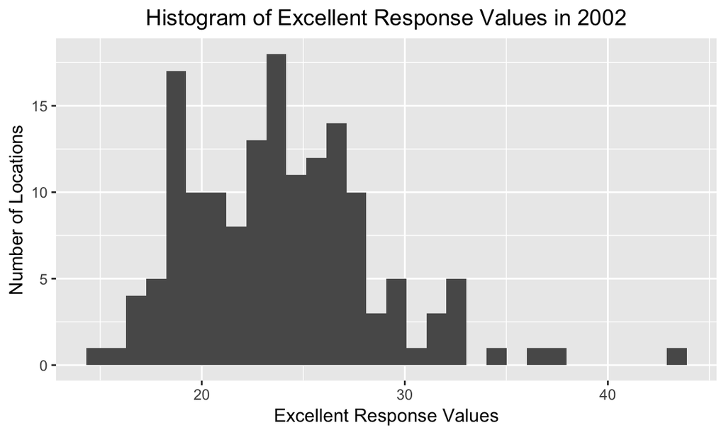

```r
# Create histogram of excellent response values
ggplot(brfss02, aes(x = Excellent)) +
  geom_histogram() +
  labs(x = "Excellent Response Values", y = "Number of Locations", title = "Histogram of Excellent Response Values in 2002") +
  theme(plot.title = element_text(hjust=0.5))
```

In the **Histogram of Excellent Response Values in 2002**, the x axis represents the **excellent response values** and the y axis represents the **number of locations** that got the corresponding values. From the histogram, we can see that the excellent response values in most locations are between 15 to 30. As the mean (23.9580645) is slightly larger than median (23.6), the histogram is slightly right skewed.

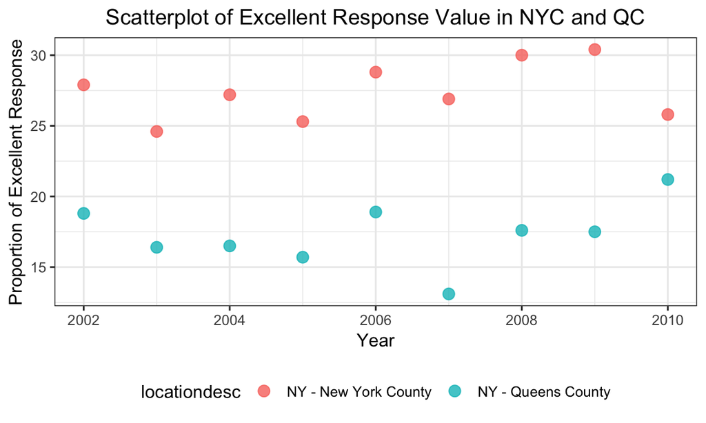

```r
# filter the data
data_nycqc = brfss_data %>%
  filter(locationdesc == "NY - New York County"| locationdesc == "NY - Queens County")

# Create scatterplot of excellent response values in NYC and QC
ggplot(data_nycqc, aes(x = year, y = Excellent, color = locationdesc)) +
  geom_point(size = 3, alpha = .8) +
  labs(x = "Year", y = "Proportion of Excellent Response", title = "Scatterplot of Excellent Response Value in NYC and QC") +
  theme_bw() +
  theme(legend.position = "bottom", plot.title = element_text(hjust=0.5))
```

In the **Scatterplot of Excellent Response Value in NYC and QC**, the x axis represents *year* and the y axis represents the *proportion of excellent response*. The blue points represent *Queens County* in New York State and the pink points represent the *New York County* in New York State.

We can see that the proportion of excellent response of New York County from 2002 to 2010 are all *higher* than Queens County.